# Public Mutation Database and Ovarian Cancer Survival Analysis

# I. Objectives

The best way to learn how to work with cancer genomic data analysis is to use the public big data freely accessible by anyone. Cancer’s main etiology is somatic mutations and therefore it is natural that NGS is applied to analyzing cancer genomics. Germline DNA does not get mutated easily throughout lifespan, but cancer DNAs undergo a variety of mutations, which is detected by NGS. Humanity’s approach to curing cancer is to make a big ass repository where all sorts of cancer genomics data are stored and use collective intelligence to tackle the problem. We will see how a data analysis over TCGA public multi-omics data resulted in a magnificent study published in JAMA. We will also learn how we can utilize genomic big data in our research by looking at the example of BRCA1 and BRCA2 variation and consequent survival analysis.

# II. Introduction

TCGA provides integrative repository of genomic, transcriptomic, epigenomic, and clinical data over 33 types of cancer. In this chapter, the results from study “Association of BRCA1 and BRCA2 mutations with survival in ovarian cancer”[^1] is reproduced. This study elucidated the role of BRCA1 and BRCA2 mutation and methylation associated with ovarian cancer, which had been quite a controversy up till that time. Also, this paper achieves the feat of publishing in one of the most prestigious journals only by using the publicly available TCGA data. It also signaled the paradigm shift from experiment-centered to data-centered science.

I dare say that cancer is a disease of genome itself, accompanying countless mutations. It is dire that we are able to discern the source of mutation in a data: whether it is from a germline mutation or a somatic mutation. The study we are referring to removed germline mutations discovered in the patients’ blood samples from ovarian tissue sample data of BRCA1 and BRCA2 mutations, which leaves us with only somatic mutations to look at. (Q: But aren’t there germline mutations that contribute to the predisposition to cancer?) BRCA1 methylation data is obtained from methylation chip experimental results. For simplicity, regarding convenience and purpose of this practice, we only use data from 500 probes.

- somatic mutation data: JAMA_Mutation.txt
- DNA methylation data: JAMA_BRCA1_Methyl.txt
- Microarray data: JAMA_Expression.txt (gene expression data of only 500 probes -> RNA)
- Clinical variable data: JAMA_Clinical.csv

Each file looks like the following:

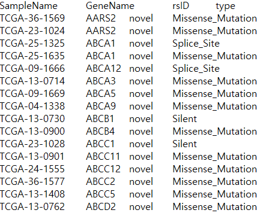

JAMA_Mutation

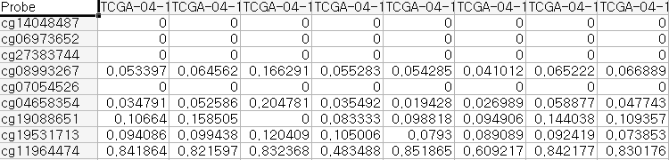

JAMA_BRCA1_Methyl

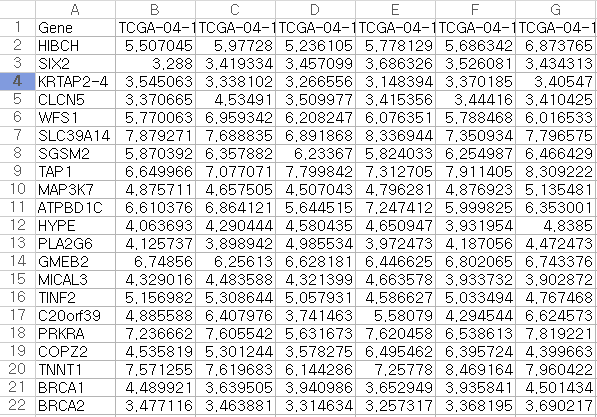

JAMA_Expression

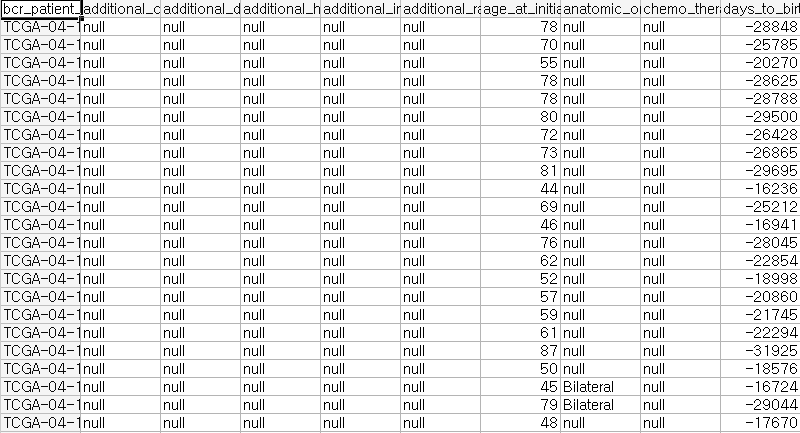

JAMA_Clinical